# Comparing Middlesex County, NJ and Arlington County, VA

Teja Pristavec

November 29, 2019

We want to compare Middlesex County, NJ and Arlington County, VA on select socioeconomic characteristics. We use 2013-17 [5 year estimates](https://www.census.gov/programs-surveys/acs/guidance/estimates.html) from the [American Community Survey](https://www.census.gov/programs-surveys/acs/technical-documentation.html) (ACS), which contains detailed population data.

# 1 Getting ACS data

ACS is structured as [tables](https://factfinder.census.gov/faces/affhelp/jsf/pages/metadata.xhtml?lang=en&type=dataset&id=dataset.en.ACS_17_5YR), so we’ll first specify which tables and table rows we want to request. To calculate population proportions later, we’ll need both the rows of interest (e.g. Hispanic population) and rows with population totals (e.g. total population).

```r
acsvars <- c(
  # educational attainment (age 25+)
  "B15003_001", "B15003_002", "B15003_003", "B15003_004", "B15003_005",
  "B15003_006", "B15003_007", "B15003_008", "B15003_009", "B15003_010",
  "B15003_011", "B15003_012", "B15003_013", "B15003_014", "B15003_015",
  "B15003_016", "B15003_017", "B15003_018",
  # income under poverty level
  "B17020_001", "B17020_002",
  # age 65+
  "B01001_001", "B01001_020", "B01001_021", "B01001_022", "B01001_023",
  "B01001_024", "B01001_025", "B01001_044", "B01001_045", "B01001_046",
  "B01001_047", "B01001_048", "B01001_049",
  # hispanic
  "B03003_001", "B03003_003",
  # black
  "B02001_001", "B02001_003",
  # family households
  "B09019_002",  "B09019_003",
  # foreign-born
  "B05002_001", "B05002_013",
  # public assistance or food stamps/snap
  "B19058_001", "B19058_002",
  # in labor force
  "B23025_001", "B23025_002",
  # renters
  "B25003_001", "B25003_003")
```

We load `tidycensus` and make a call to the ACS API. We call states and counties by their Federal Information Processing Standard ([FIPS](https://www.census.gov/geographies/reference-files/2017/demo/popest/2017-fips.html)) codes.

```r
library(tidycensus)

# Get county-level variables from ACS 2013-17 for NJ
acsdata_nj <- get_acs(geography = "county", state = 34, county = 023,
                      variables = acsvars, year = 2017, survey = "acs5",
                      cache_table = TRUE, output = "wide")

# Get county-level variables from ACS 2013-17 for VA
acsdata_va <- get_acs(geography = "county", state = 51, county = 013,
                      variables = acsvars,  year = 2017, survey = "acs5",
                      cache_table = TRUE, output = "wide")
```

Each call returns a single row of data – we requested information at county level for one county, once for NJ and once for VA – with estimates on select variables (names ending with `E`) and their corresponding 90% margins of error (`M`). We’ll discard the margins of error for this exercise and work with point estimates only.

```r
head(names(acsdata_nj))
```

```
## [1] "GEOID"       "NAME"        "B15003_001E" "B15003_001M" "B15003_002E"
## [6] "B15003_002M"
```

# 2 Calculating population proportions

Since we don’t want to keep the original variables, we use `transmute` instead of `mutate` when calculating population proportions on variables of interest (that is, dividing the count of the category of interest with the population total for that category).

```r
library(dplyr)

# Calculate proportions: NJ
acs_nj <- acsdata_nj %>% transmute(area = "NJ",
            hs_or_less = (B15003_002E + B15003_003E + B15003_004E + B15003_005E +
                          B15003_006E + B15003_007E + B15003_008E + B15003_009E +
                          B15003_010E + B15003_011E + B15003_012E + B15003_013E +
                          B15003_014E + B15003_015E + B15003_016E + B15003_017E +
                          B15003_018E) / B15003_001E,
            poverty = B17020_002E / B17020_001E,
            age_65_older = (B01001_020E + B01001_021E + B01001_022E + B01001_023E +
                            B01001_024E + B01001_025E + B01001_044E + B01001_045E +
                            B01001_046E + B01001_047E + B01001_048E + B01001_049E) /
                            B01001_001E,
            hispanic = B03003_003E / B03003_001E,
            black = B02001_003E / B02001_001E,
            family = B09019_003E / B09019_002E,
            foreign = B05002_013E / B05002_001E,
            assistance = B19058_002E / B19058_001E,
            laborforce = B23025_002E / B23025_001E,
            renters = B25003_003E / B25003_001E)

# Calculate proportions: VA
acs_va <- acsdata_va %>% transmute(area = "VA",
            hs_or_less = (B15003_002E + B15003_003E + B15003_004E + B15003_005E +
                          B15003_006E + B15003_007E + B15003_008E + B15003_009E +
                          B15003_010E + B15003_011E + B15003_012E + B15003_013E +
                          B15003_014E + B15003_015E + B15003_016E + B15003_017E +
                          B15003_018E) / B15003_001E,
            poverty = B17020_002E / B17020_001E,
            age_65_older = (B01001_020E + B01001_021E + B01001_022E + B01001_023E +
                            B01001_024E + B01001_025E + B01001_044E + B01001_045E +
                            B01001_046E + B01001_047E + B01001_048E + B01001_049E) /
                            B01001_001E,
            hispanic = B03003_003E / B03003_001E,
            black = B02001_003E / B02001_001E,
            family = B09019_003E / B09019_002E,
            foreign = B05002_013E / B05002_001E,
            assistance = B19058_002E / B19058_001E,
            laborforce = B23025_002E / B23025_001E,
            renters = B25003_003E / B25003_001E)
```

We bind rows and get a single dataframe with values for Middlesex County, NJ and Arlington County, VA.

```r
acsdata <- rbind(acs_nj, acs_va)
head(acsdata)
```

```
## # A tibble: 2 x 11
##   area  hs_or_less poverty age_65_older hispanic  black family foreign
##   <chr>      <dbl>   <dbl>        <dbl>    <dbl>  <dbl>  <dbl>   <dbl>
## 1 NJ         0.365  0.0858       0.138     0.204 0.100   0.881   0.326
## 2 VA         0.141  0.0816       0.0983    0.155 0.0883  0.653   0.229
## # … with 3 more variables: assistance <dbl>, laborforce <dbl>, renters <dbl>
```

# 3 Lolli-plotting

Before we can create a lolliplot chart, we’ll have to reshape our data to long. We’ll also add a range midpoint variable that we can use to sort our plot later, and clean up our `names` column.

```r
library(tidyr)

# Pivot to long
acs_nj_long <- acs_nj %>%
               pivot_longer(cols = 2:11, values_to = "val13") %>%
               select(-area)

acs_va_long <- acs_va %>%
               pivot_longer(cols = 2:11, values_to = "val17") %>%
               select(-area)

# Join and arrange by range mean
ctydata <- left_join(acs_nj_long, acs_va_long, by = "name") %>%
           mutate(meanpoint = (val13 + val17) / 2) %>%
           arrange(desc(meanpoint))

# Clean up names
ctydata$name <- c("Family households", "In labor force", "Renters", "Foreign-born",
                  "High school or less", "Hispanic", "Age 65+", "Black", "In poverty",
                  "Social assistance")

ctydata$name <- factor(ctydata$name,
                       levels = c("Family households", "In labor force", "Renters",
                                  "Foreign-born", "High school or less", "Hispanic",
                                  "Age 65+", "Black", "In poverty", "Social assistance"))

# Look at the data
ctydata
```

```
## # A tibble: 10 x 4
##    name                 val13  val17 meanpoint
##    <fct>                <dbl>  <dbl>     <dbl>
##  1 Family households   0.881  0.653     0.767
##  2 In labor force      0.647  0.783     0.715
##  3 Renters             0.364  0.555     0.460
##  4 Foreign-born        0.326  0.229     0.277
##  5 High school or less 0.365  0.141     0.253
##  6 Hispanic            0.204  0.155     0.180
##  7 Age 65+             0.138  0.0983    0.118
##  8 Black               0.100  0.0883    0.0943
##  9 In poverty          0.0858 0.0816    0.0837
## 10 Social assistance   0.0681 0.0424    0.0553
```

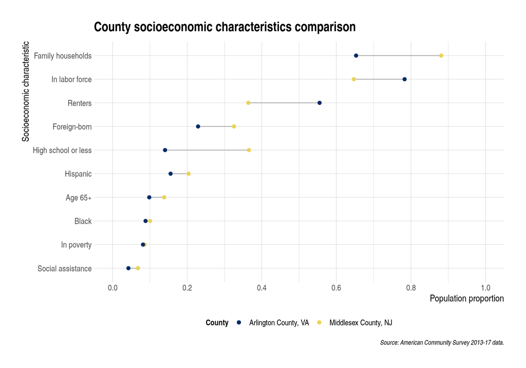

```r
library(ggplot2)
library(viridis)
library(scales)
library(forcats)
library(hrbrthemes)

# Plot
ggplot(ctydata) +
  geom_segment(aes(x = reorder(name, meanpoint), xend = name, y = val13, yend = val17),
               color = "darkgrey") +
  geom_point(aes(x = reorder(name, meanpoint), y = val13, color = "Middlesex County, NJ"),
             size = 2) +
  geom_point(aes(x = reorder(name, meanpoint), y = val17, color = "Arlington County, VA"),
             size = 2) +
  coord_flip() +
  theme_ipsum() +
  scale_y_continuous(breaks = seq(0, 1, 0.20), limits = c(0, 1)) +
  labs(x = "Socioeconomic characteristic", y = "Population proportion",
       caption = "Source: American Community Survey 2013-17 data.",
       title = "County socioeconomic characteristics comparison") +
  theme(legend.position = "bottom",
        axis.title.x = element_text(size = 13),
        axis.title.y = element_text(size = 13),
        legend.title = element_text(size = 11, face = "bold"),
        legend.text = element_text(size = 11)) +
  scale_colour_manual(values = c("#002C6A", "#EAD357"), name = "County")
```